# Total Protein analysis in the TEM project

Marie Locard-Paulet

28/09/2015

Raw files are the following:

- experiment labelled “MLP”: files `20130211_MLP_363282_gb97A to J` are 10 gel bands of an independent co-culture experiment of MDA-MB-231-LM2 (labelled Heavy) and HUVECs (light), using MDA-MB-231-LM2 (medium) in suspension as control. This experiment has been performed exactly like SILAC010, SILAC011, SILAC12, SILAC013 and SILAC017 (Experiments A to E in the supplementary tables of the paper). The gel bands have been digested (in-gel) and subjected to LC-MSMS on the orbitrap Velos.
- Off-line HpH RP-HPLC fractions (19 per sample) of peptides from cytoplasmic fractions of the following experiments (done by Kelly McMahon):
- “MLP1” = SILAC012/psMLP113 (cytoplasmic fraction of labelled LM2, experiment C in the paper)
- “MLP2” = SILAC011/psMLP125 (cytoplasmic fraction of labelled LM2, experiment B in the paper)
- “MLP3” = SILAC013/psMLP129 (cytoplasmic fraction of labelled LM2, experiment D in the paper)
- “MLP4” = SILAC014 (cytoplasmic fraction of labelled HUVECs, experiment F in the paper)
- “MLP5” = SILAC015 (cytoplasmic fraction of labelled HUVECs, experiment G in the paper)
- “MLP6” = SILAC016 (cytoplasmic fraction of labelled HUVECs, experiment H in the paper)
- EPHA2-IP performed by Lindsay Lim (in the folder EPHA2-IP): She did two independent co-culture experiments with LM2 and HUVEC, using medium-labelled LM2 cells as a monoculture sample (exactly like the main phospho-experiment of the paper). Then she lysed in PLC buffer and performed an IP. I have 2 experiment results (CC1 and CC2).

I open the files searched in Proteome Discoverer (all fractions ran together) and analyse all SILAC Heavy and Medium intensities with no intensity threshold first: files names `..._NoQuanThreshold` in the folders `Analysis_2` and `EPHA2-IP`. for each file, I calculate the 5% quantile of Median and Heavy labels intensities combined and use it as a threshold for the quantification.

Raw files are then reanylised with this threshold in PD1.4 and I export the ungroupped peptide tables, proteins still grouped: files `..._QuanThreshold`.

```r
quan <- c(list.files(path = "Analysis_2/NoQuanThreshold/", pattern = ".csv"), list.files(path = "EPHA2-IP/NoQuanThreshold/", pattern = ".csv"))
prot <- c(list.files(path = "Analysis_2/QuanThreshold/", pattern = ".csv"), list.files(path = "EPHA2-IP/QuanThreshold/", pattern = ".csv"))
```

```r
Create_Files_list <- function(FileNames) {# read ;csv for all file names in the working directory.
  l <- list()
  for (f in FileNames) {
  l[[length(l)+1]] <- read.delim(f, sep = ";", header = T, stringsAsFactors = F)
  }
  names(l) <- FileNames
  l
}
Normalisation_peptide_table <- function(table) {
  table <- table[table$PEP <= 0.01,]
  table <- table[!grepl("|", table$Protein.Description, fixed = T),]
  table <- table[!is.na(table$Heavy.Medium),]
  logHM <- log(table$Heavy.Medium, 2)
  median <- median(logHM)
  df <- data.frame(table, "log2HM" = (logHM-rep(median, nrow(table))), stringsAsFactors = F)
  df
}
AddGenes_peptide_table <- function(tab) {
  vec <- tab$Protein.Group.Accessions
  vec <- sapply(vec, function(x) strsplit(x, split="|", fixed=T)[[1]][1])
  vec <- bitr(vec, fromType = "UNIPROT", toType = "SYMBOL", annoDb = "org.Hs.eg.db")
  genes <- vec[,2][match(tab$Protein.Group.Accessions,vec[,1])]
  UniprotEntry <- tab$Protein.Description
  UniprotEntry <- sapply(1:length(UniprotEntry), function(x) strsplit(UniprotEntry[x], "- [", fixed = T)[[1]][2])
  UniprotEntry <- sapply(1:length(UniprotEntry), function(x) strsplit(UniprotEntry[x], "_", fixed = T)[[1]][1])
  tab <- data.frame(tab, "Symbol"=genes, "UniprotEntry" = UniprotEntry, stringsAsFactors = F)
  tab
}
```

# Protein quantification

## Defining threshold for quantification

I cannot choose different thresholds for the 2 channels in PD so I decide on the 5% quantile of the combined intensities: Median and Heavy. Here are presented the different thresholds in the different files (red line on the intensity distributions).

Primary filter: PEP below or equal to 0.01.

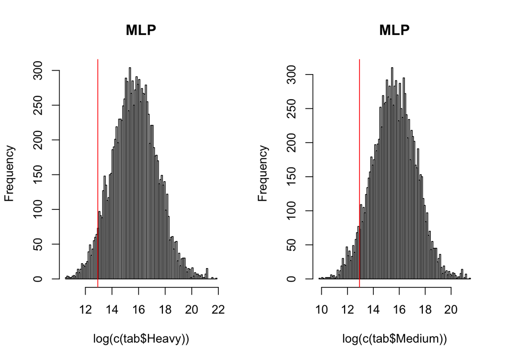

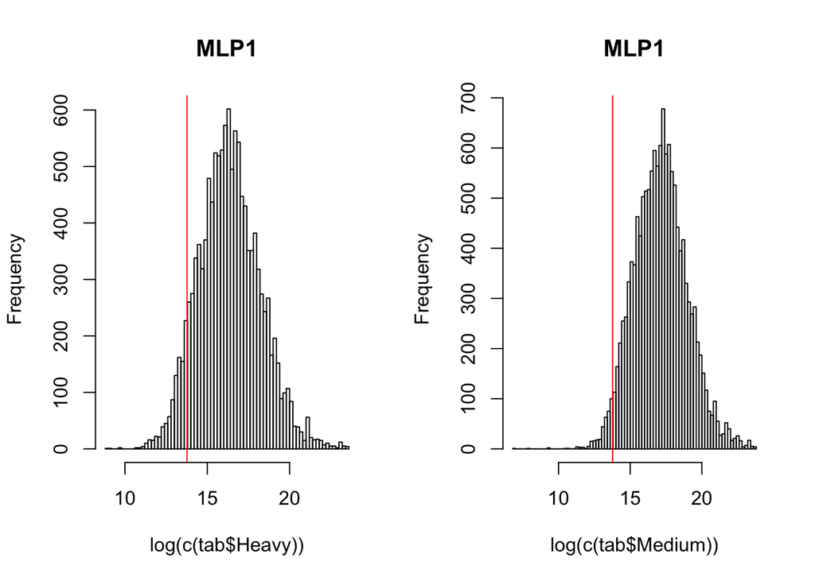

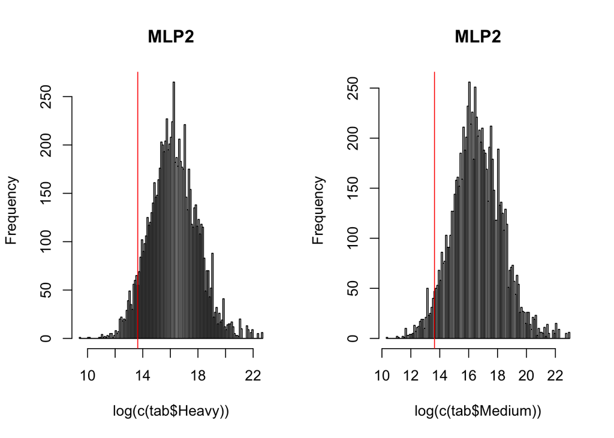

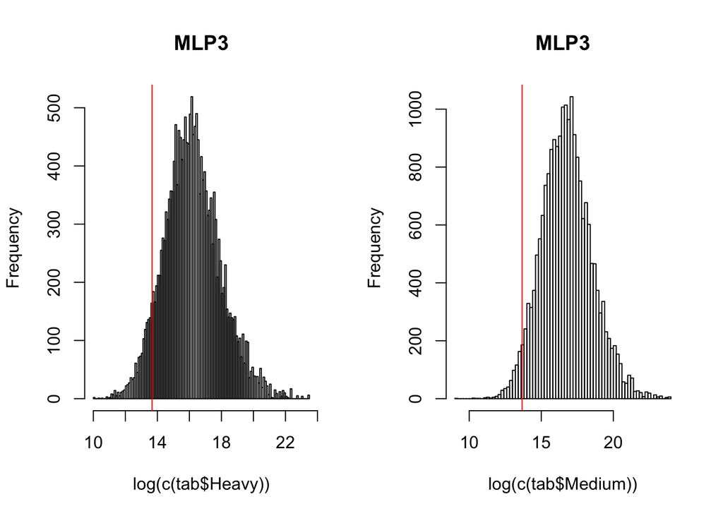

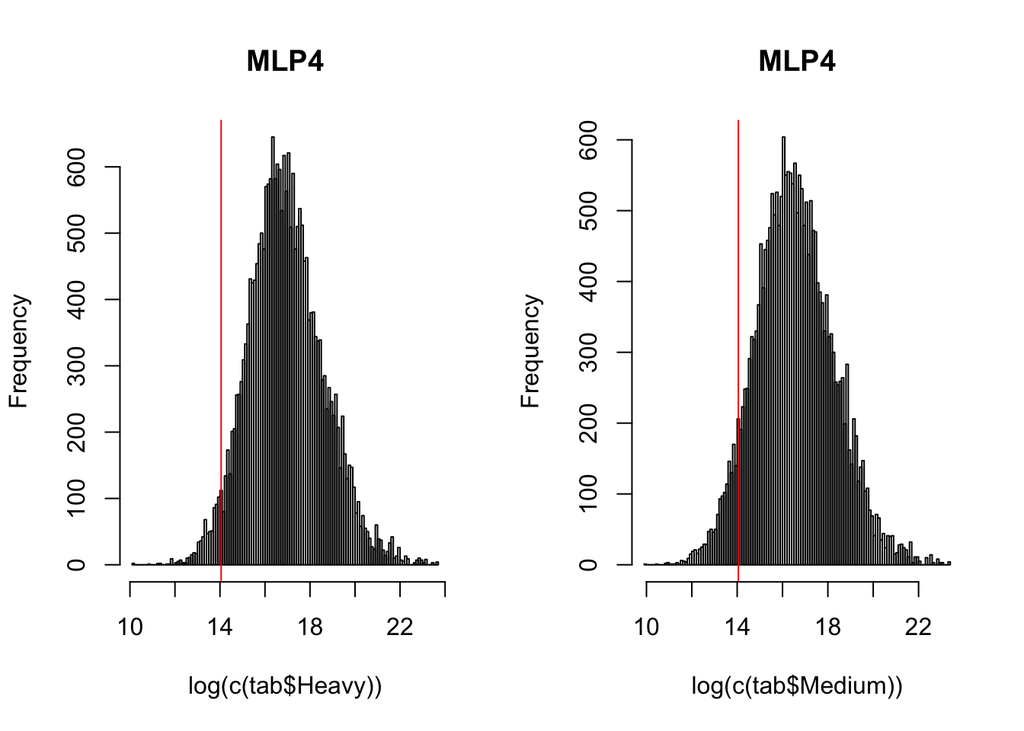

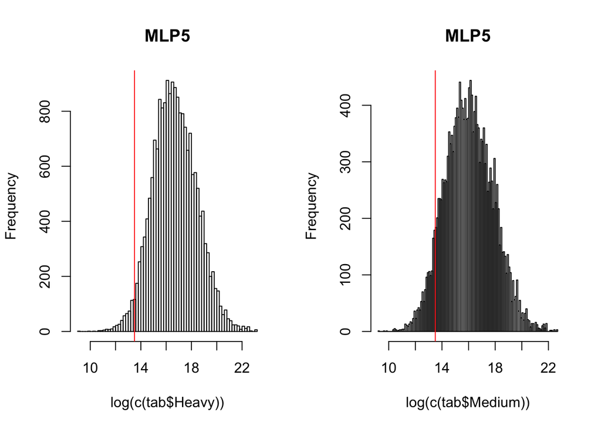

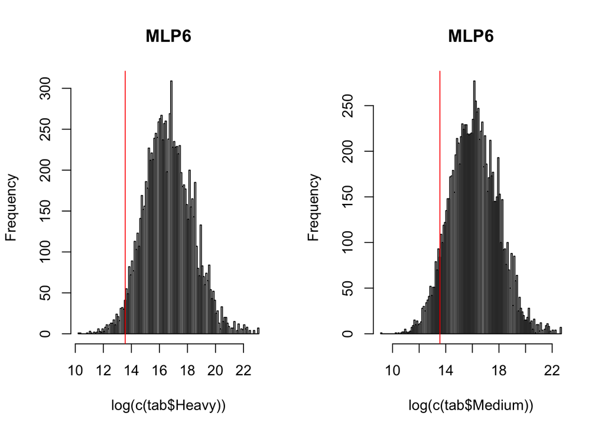

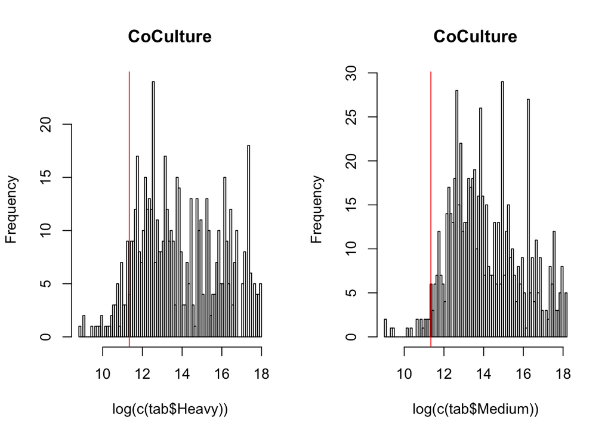

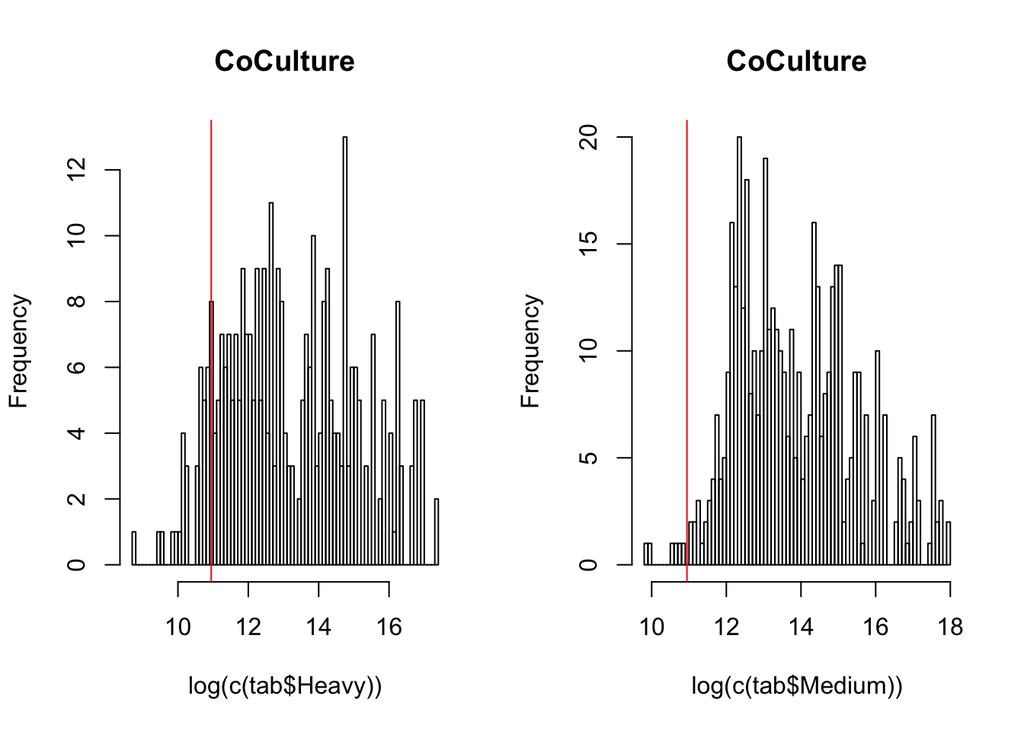

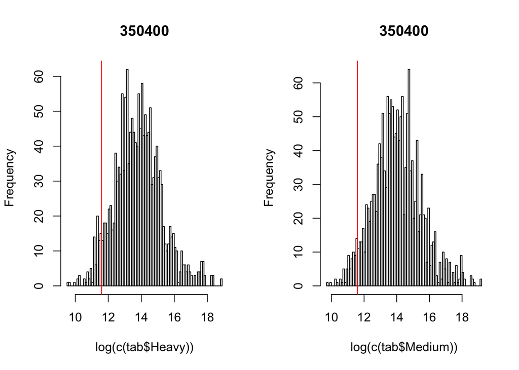

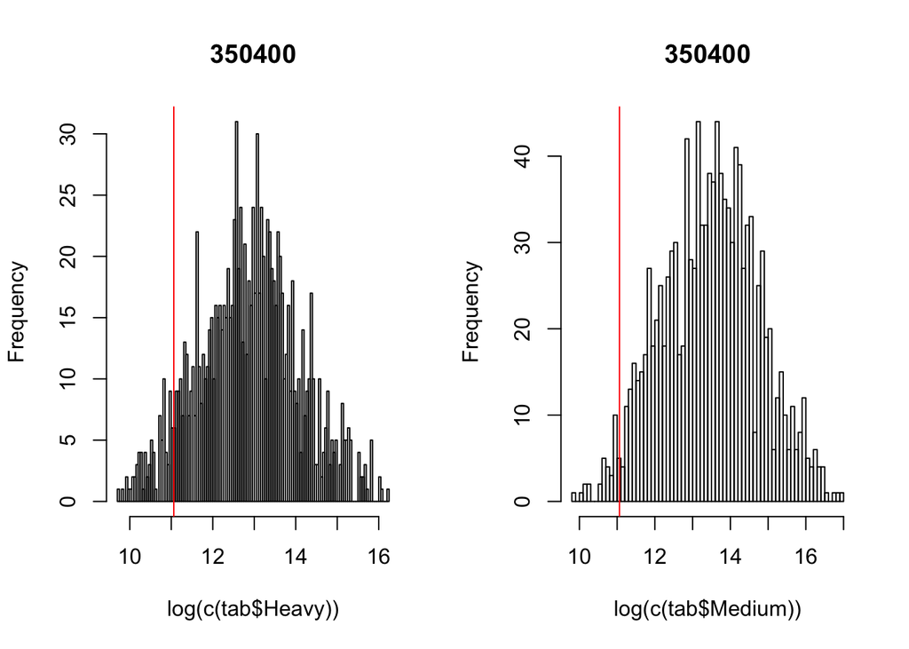

```r
FileNames <- vector(length = length(quan))
FileNames[!grepl("_LL", quan)] <- sapply(quan[!grepl("_LL", quan)], function(x) paste0("Analysis_2/NoQuanThreshold/", x))
FileNames[grepl("_LL", quan)] <- sapply(quan[grepl("_LL", quan)], function(x) paste0("EPHA2-IP/NoQuanThreshold/", x))
l <- Create_Files_list(FileNames)

normfactors <- vector(length = length(l))
for (i in 1:length(l)) {
  tab <- l[[i]]
  threshold <- quantile(c(tab$Heavy, tab$Medium), 0.05, na.rm = T)
  par(mfrow=c(1,2))
  hist(log(c(tab$Heavy)), breaks = 100, main = strsplit(names(l)[i], "_")[[1]][3])
  abline(v = log(threshold), col = "red")
  hist(log(c(tab$Medium)), breaks = 100, main =strsplit(names(l)[i], "_")[[1]][3])
  abline(v = log(threshold), col = "red")
  normfactors[i] <- threshold
  names(normfactors)[i] <- strsplit(names(l)[i], "_")[[1]][3]
}
```

Graphs labelled 350400 are the input of the IP. These will be used for normalisation of the mix in the IP samples.

Thresholds for MLP, MLP1, MLP2, MLP3, MLP4, MLP5, MLP6, CoCulture, CoCulture, 350400, 350400 are the following: 4.137510^{5}, 9.560410^{5}, 8.36610^{5}, 8.6441510^{5}, 1.266510^{6}, 7.28210^{5}, 7.74610^{5}, 8.4220510^{4}, 5.6710^{4}, 1.088110^{5}, 6.362810^{4}, respectively. I use these values as a threshold for calculating the SILAC heavy/Medium ratio (H/M) for each peptide.

## Protein quantification with higher intensity peptides

For each protein, I calculate the mean of the log2(H/M) ratios of the 3 most intense peptides. The IP values are systematically normalised by the input SILAC ratios.

```r
FileNames <- vector(length = length(prot))
FileNames[!grepl("_LL", prot)] <- sapply(prot[!grepl("_LL", prot)], function(x) paste0("Analysis_2/QuanThreshold/", x))
FileNames[grepl("_LL", prot)] <- sapply(prot[grepl("_LL", prot)], function(x) paste0("EPHA2-IP/QuanThreshold/", x))
l <- Create_Files_list(FileNames)

l2 <- list()
for (i in 1:7) {
  l2[[length(l2)+1]] <- Normalisation_peptide_table(l[[i]])
}
for (i in 8:11) {
  table <- l[[i]]
  table <- table[table$PEP <= 0.01,]
  table <- table[!grepl("|", table$Protein.Description, fixed = T),]
  table <- table[!is.na(table$Heavy.Medium),]
  logHM <- log(table$Heavy.Medium, 2)
  df <- data.frame(table, "log2HM" = logHM, stringsAsFactors = F)
  l2[[length(l2)+1]] <- df
}


med1 <- median(l2[[10]]$log2HM, na.rm = T)
med2 <- median(l2[[11]]$log2HM, na.rm = T)

l2[[8]]$log2HM <- l2[[8]]$log2HM-med1
l2[[9]]$log2HM <- l2[[9]]$log2HM-med2

names(l2) <- names(l)
l <- list(l2[[1]], l2[[2]], l2[[3]], l2[[4]], l2[[5]], l2[[6]],l2[[7]], l2[[8]], l2[[9]])
names(l) <- names(l2)[1:9]

Values <- list()
protTab <- list()
for (i in 1:length(l)) {
  tab <- l[[i]]
  #tab <- Normalisation_peptide_table(tab)
  tab <- tab[order(tab$Sequence),]
  tab <- tab[!duplicated(tab$Sequence),]
  proteins <- unique(tab$Protein.Descriptions)
  output1 <- matrix(ncol = ncol(tab), nrow = 1)
  dimnames(output1)[[2]] <- names(tab)
  mean <- list()
  sd <- list()
  for (el in proteins) {
    sub <- subset(tab[tab$Protein.Descriptions==el,])
    sub <- sub[!duplicated(sub$QuanResultID),]
    sumInt <- sub$Heavy + sub$Medium
    sub <- sub[order(sumInt, decreasing = T),]
    sub <- sub[1:3,]
    output1 <- rbind(output1, sub)
    mean[[length(mean)+1]] <- mean(sub$log2HM, na.rm = T)
    sd[[length(sd)+1]] <- sd(sub$log2HM, na.rm = T)
  }
  mean <- unlist(mean)
  sd <- unlist(sd)
  protTab[[length(protTab)+1]] <- data.frame("Protein.Description"=proteins, "Mean" = mean, "StandardDev" = sd)
  names(protTab)[length(protTab)] <- names(l)[i]
  Values[[length(Values)+1]] <- output1
  names(Values)[length(Values)] <-  names(l)[i]

  #plot(-log10(protTab[[length(protTab)]]$StandardDev)~protTab[[length(protTab)]]$Mean)
}

protTab2 <- protTab
Values2 <- Values
```

# MDA-MB-231-LM2

Firstly, I work with the tables of LM2 samples.

I am looking for the following proteins of interest (presented in the figure 2 of the paper - these proteins have regulated phosphosites with 0.5 <= log2(H/M) <= -0.5): TLN1, LMNA, TPD52, EGFR, F125A, STIM1, FMNL, ARAP3, PTRF, ARHG2, CLIP1, CLIP2, RL28, STMN1, FLNA, H4, AHNAK, KI67, DHCR7, GTR1, CD97, ITPR3, IQGA1, PAR2, FUND2, H14, LIPB1, RAF1, CYTSB, TPD54, PECA1, NUCL, KPCA, NPM, RAF1, RHG35, HUWE1, KTN1, PALLD, RBM7, MPRIP, SSFA2, AFAP1, PAXI, CD44, SRS11, HSPB1, BOK, LIMD2, PAK2, SVIL, ANLN, EPHA2, MK01, PININ, VIME, PEA15, STK10, ITB4, AKAP2, MYPT1.

I keep only the peptides with a PEP <= 0.01.

## Protein quantification

I calculate the log2(H/M) ratios per peptides and I normalise to the median of the log2(H/M) ratios of the entire sample.

```r
intNames <- FileNames[grepl("_MLP1_", FileNames) | grepl("_MLP2_", FileNames) | grepl("_MLP3_", FileNames) | grepl("_MLP_", FileNames) | grepl("CoCulture", FileNames)] # Select files of labelled LM2

protTab <- list()
for (i in 1:length(protTab2)) {
  if (names(protTab2)[i] %in% intNames) { protTab[[length(protTab)+1]] <- protTab2[[i]] }
}
names(protTab) <- names(protTab2)[names(protTab2) %in% intNames]
```

## Median for all experiments

I calculate the median of log2(H/M) ratio per protein and the standard deviation. All the obtained values are plotted in the following boxplot.The distribution of the log2(H/M) per protein are presented in a volcano plot (y is the -log10(%CV)) and the corresponding density on the top.

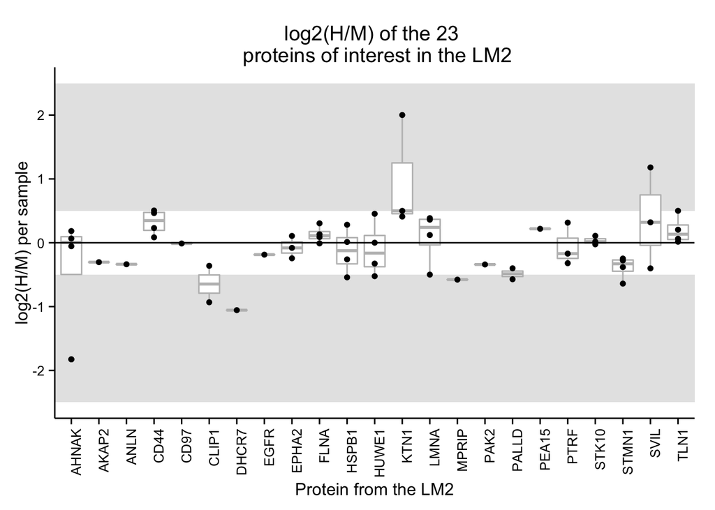

```r
tab <- protTab[[1]]
names(tab) <- c(names(tab)[1], sapply(names(tab)[2:length(names(tab))], function(x) paste0(x, "_", strsplit(names(protTab)[1], "_")[[1]][3])))
for(i in 2:length(protTab)) {
  tab <- merge(tab, protTab[[i]], by = "Protein.Description", all = T)
  names(tab)[(length(names(tab))-1):length(names(tab))] <- sapply(c("Mean", "StandardDev"), function(x) paste0(x, "_", strsplit(names(protTab)[i], "_")[[1]][3]))
}

med <- sapply(1:nrow(tab), function(x) median(as.numeric(tab[x,grepl("Mean_", names(tab))]), na.rm =T))
sd <- sapply(1:nrow(tab), function(x) sd(tab[x,grepl("Mean_", names(tab))], na.rm = T))
n <- sapply(1:nrow(tab), function(x) length(tab[x,grepl("Mean_", names(tab))][!is.na(tab[x,grepl("Mean_", names(tab))])]))
names(med) <- tab$Protein.Description
names(sd) <- tab$Protein.Description
names(n) <- tab$Protein.Description
perc <- length(med[med>=0.5 | med <= -0.5])/length(med)*100

means3 <- med[n>=3]
sd3 <- sd[n>=3]

perc3 <- length(means3[means3>=0.5 | means3 <= -0.5])/length(means3)*100

Symbol <- sapply(as.character(tab$Protein.Description), function(x) strsplit(x, "GN=")[[1]][2])
Symbol <- sapply(Symbol, function(x) strsplit(x, " ")[[1]][1])
element <- tab[Symbol %in% LM2prot,]
export <- element
write.csv(element, "OutputTab/MedianMDAs.csv", row.names = F)
nr <- nrow(element)
element <- data.frame("Symbol"=rep(Symbol[Symbol %in% LM2prot], 6), "Median" = c(element[,2], element[,4], element[,6], element[,8], element[,10], element[,12]), "Exp" = rep(c("MLP", "MLP1", "MLP2", "MLP3", "IP1", "IP2"), each = nr))

gg <- ggplot(element, aes(x = Symbol, y = Median)) + geom_rect(xmax = nrow(element), xmin = 0, ymax = 2.5, ymin = 0.5, fill = "gray90") + geom_rect(xmax = nrow(element), xmin = 0, ymax = -0.5, ymin = -2.5, fill = "gray90") + geom_boxplot(col = "grey") + theme_classic()  + geom_hline(yintercept = 0)
print(gg + geom_point() + ylab("log2(H/M) per sample") + xlab("Protein from the LM2") + ggtitle("log2(H/M) of the 23 \n proteins of interest in the LM2") + theme(axis.text.x = element_text(angle = 90, hjust = 1)) + ylim(-2.5,2.5))
```

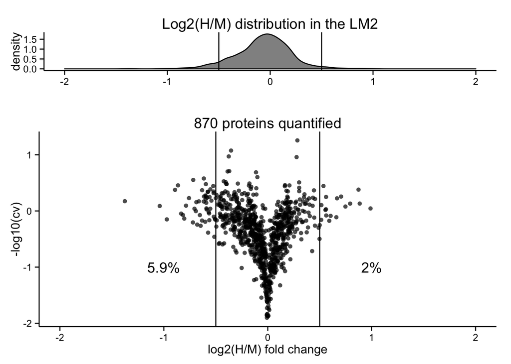

```r
tab1 <- tab[n >=3,]
pval <- sapply(1:nrow(tab1), function(x) t.test(tab1[x,c(2, 4, 6, 8, 10, 12)], alternative = "two.sided")$p.value)
mean2 <- med[n>=3]
col <- rep("not regulated", nrow(tab1))
col[pval<=0.05 & (mean2 >= 0.5 | mean2 <= -0.5)] <- "regulated"
df <- data.frame(tab1, "pval" = pval, "FC" = mean2, "col" = col)

sd <- sapply(1:nrow(df), function(x) sd(df[x,c(2,4,6,8, 10, 12)], na.rm = T))
cv <- sd/abs(df$FC)
df <- data.frame(df, "sdev" = sd, "cv" = cv)
df <- df[df$cv<80,]

p <- length(unique(as.character(df$Protein.Description)))
ppos <- length(unique(as.character(df$Protein.Description[df$FC>=0.5])))
pneg <- length(unique(as.character(df$Protein.Description[df$FC<=-0.5])))

scatter <- ggplot(df, aes(x = FC, y = -log10(cv))) + geom_point(alpha = 0.7, fill = "black") + theme_classic() + geom_vline(xintercept = c(-0.5, 0.5)) + annotate("text", x = -1, y = -1, label = paste0(round(pneg/p*100,1), "%")) + annotate("text", x = 1, y = -1, label = paste0(round(ppos/p*100,1), "%")) + ggtitle(paste0(p, " proteins quantified")) + xlim(-2,2) + xlab("log2(H/M) fold change")

plot_top <- ggplot(df, aes(x = FC)) + geom_density(alpha = 0.5, fill = "black") + theme(legend.position = "none") + theme_classic() + geom_vline(xintercept = c(-0.5, 0.5)) + theme(axis.title.x = element_blank()) + ggtitle("Log2(H/M) distribution in the LM2") + xlim(-2,2)

print(grid.arrange(plot_top, scatter, ncol=1, nrow=2, heights=c(1.5, 4)))
```

Among the 870 proteins quantified across a minimum of 3 independent experiments, 7.816092% are regulated based on a threshold of -0.5 >= log2H/M >=0.5 (with a CV < 80%).

# HUVEC

I am looking for the following proteins of interest: AHNAK, EPHA2, MK14, STMN1, MK03, RHG01, SUN2, PEA15, PTRF, NOS3, ZYX, HSPB1, ITPR3, FLNA, CTNB1, MK01, MENTO, P4K2A, MELT, NEST, CTND1, PKN2, CI142, ACVL1, BNIP2, TPD54, AMPD2, NIBL1, K1C18, PDLI4, MAP4, ITB4, CLCN7. These are the uniprot entry names. Tey are all the proteins in the Figure 2 of the paper: all regulated proteins with fold change threshold, no stat.

I keep only the peptides with a PEP <= 0.01.

## Protein quantification

Exactly like performed on the LM2.

## Median for all experiments

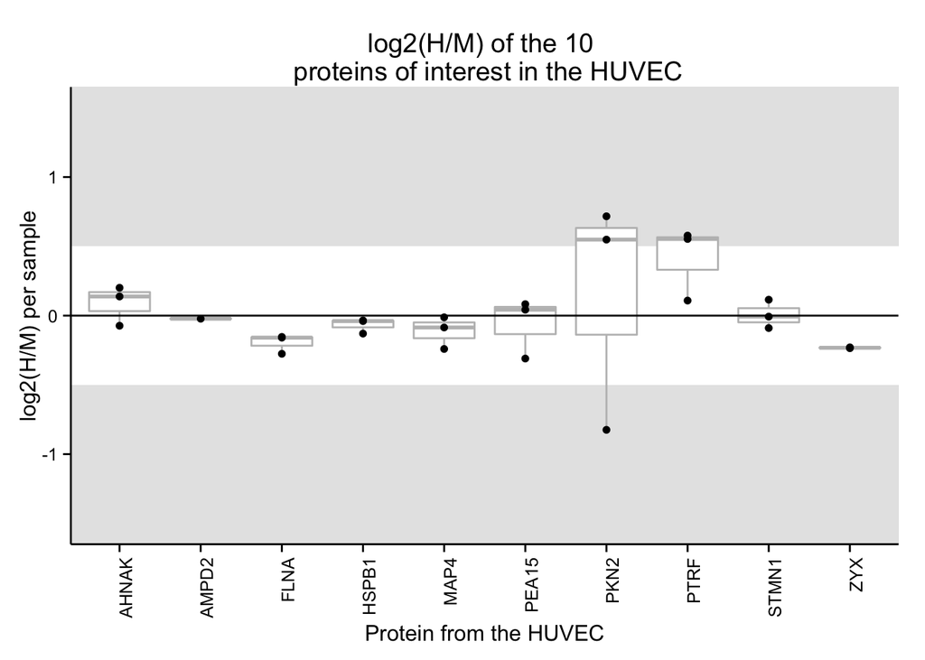

```r
tab <- protTab[[1]]
names(tab) <- c(names(tab)[1], sapply(names(tab)[2:length(names(tab))], function(x) paste0(x, "_", strsplit(names(protTab)[1], "_")[[1]][3])))
for(i in 2:length(protTab)) {
  tab <- merge(tab, protTab[[i]], by = "Protein.Description", all = T)
  names(tab)[(length(names(tab))-1):length(names(tab))] <- sapply(c("Mean", "StandardDev"), function(x) paste0(x, "_", strsplit(names(protTab)[i], "_")[[1]][3]))
}

med <-rowMeans(tab[,grepl("Mean_", names(tab))], na.rm =T)
sd <- sapply(1:nrow(tab), function(x) sd(tab[x,grepl("Mean_", names(tab))], na.rm = T))
n <- sapply(1:nrow(tab), function(x) length(tab[x,grepl("Mean_", names(tab))][!is.na(tab[x,grepl("Mean_", names(tab))])]))
names(med) <- tab$Protein.Description
names(sd) <- tab$Protein.Description
names(n) <- tab$Protein.Description
perc <- length(med[med>=0.5 | med <= -0.5])/length(med)*100

means3 <- med[n==3]
sd3 <- sd[n==3]

perc3 <- length(means3[means3>=0.5 | means3 <= -0.5])/length(means3)*100

Symbol <- sapply(as.character(tab$Protein.Description), function(x) strsplit(x, "GN=")[[1]][2])
Symbol <- sapply(Symbol, function(x) strsplit(x, " ")[[1]][1])
element <- tab[Symbol %in% HUVprot,]
export <- element
write.csv(element, "OutputTab/MediansHUV.csv", row.names = F)
nr <- nrow(element)
element <- data.frame("Symbol"=rep(Symbol[Symbol %in% HUVprot], 3), "Median" = c(element[,2], element[,4], element[,6]), "Exp" = rep(c("MLP4", "MLP5", "MLP6"), each = nr))

gg <- ggplot(element, aes(x = Symbol, y = Median)) + geom_rect(xmax = nrow(element), xmin = 0, ymax = 2, ymin = 0.5, fill = "gray90") + geom_rect(xmax = nrow(element), xmin = 0, ymax = -0.5, ymin = -2, fill = "gray90") + geom_boxplot(col = "grey") + theme_classic()  + geom_hline(yintercept = 0)
print(gg + geom_point() + ylab("log2(H/M) per sample") + xlab("Protein from the HUVEC") + ggtitle("log2(H/M) of the 10 \n proteins of interest in the HUVEC") + theme(axis.text.x = element_text(angle = 90, hjust = 1)) + ylim(-1.5, 1.5))
```

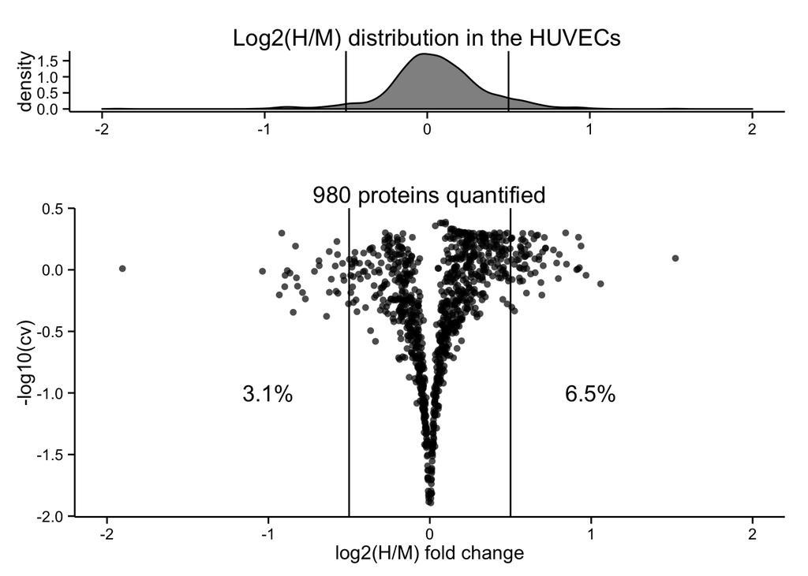

```r
tab1 <- tab[n ==3,]
pval <- sapply(1:nrow(tab1), function(x) t.test(tab1[x,c(2, 4, 6)], alternative = "two.sided")$p.value)
mean2 <- med[n==3]
col <- rep("not regulated", nrow(tab1))
col[pval<=0.05 & (mean2 >= 0.5 | mean2 <= -0.5)] <- "regulated"
df <- data.frame(tab1, "pval" = pval, "FC" = mean2, "col" = col)

sd <- sapply(1:nrow(df), function(x) sd(df[x,c(2,4,6,8)], na.rm = T))
cv <- sd/abs(df$FC)
df <- data.frame(df, "sdev" = sd, "cv" = cv)
df <- df[df$cv<80,]

p <- length(unique(as.character(df$Protein.Description)))
ppos <- length(unique(as.character(df$Protein.Description[df$FC>=0.5])))
pneg <- length(unique(as.character(df$Protein.Description[df$FC<=-0.5])))

scatter <- ggplot(df, aes(x = FC, y = -log10(cv))) + geom_point(alpha = 0.7, fill = "black") + theme_classic() + geom_vline(xintercept = c(-0.5, 0.5)) + annotate("text", x = -1, y = -1, label = paste0(round(pneg/p*100,1), "%")) + annotate("text", x = 1, y = -1, label = paste0(round(ppos/p*100,1), "%")) + ggtitle(paste0(p, " proteins quantified")) + xlim(-2,2)+ xlab("log2(H/M) fold change")

plot_top <- ggplot(df, aes(x = FC)) + geom_density(alpha = 0.5, fill = "black") + theme(legend.position = "none") + theme_classic() + geom_vline(xintercept = c(-0.5, 0.5)) + theme(axis.title.x = element_blank()) + ggtitle("Log2(H/M) distribution in the HUVECs") + xlim(-2,2)

grid.arrange(plot_top, scatter, ncol=1, nrow=2, heights=c(1.5, 4))
```

Among the 980 proteins quantified across the 3 independent experiments, 9.5918367% are regulated based on a threshold of -0.5 >= log2H/M >=0.5 (with a CV < 80%).

# Figures for the paper

## MDAs

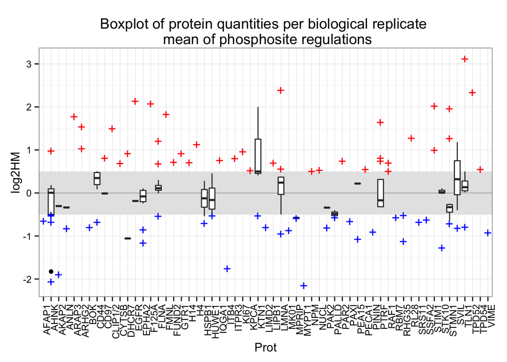

```r
tab <- read.csv("OutputTab/MedianMDAs.csv")
tabsites <- read.csv("TopHitsMDAAverages.csv")

Uniprot <- sapply(as.character(tab$Protein.Description), function(x) strsplit(x, " - [", fixed = T)[[1]][2])
Uniprot <- sapply(Uniprot, function(x) strsplit(x, "_")[[1]][1])
tab <- data.frame(tab, "Uniprot" = Uniprot)

tabsites <- tabsites[tabsites$FC >= 0.5 | tabsites$FC <= -0.5,]

tabtot <- merge(tab, tabsites, by = "Uniprot", all = T)

MedianProt <- sapply(1:nrow(tabtot), function(x) median(as.numeric(tabtot[x,c(3, 5, 7, 9, 11, 13)]), na.rm = T))
tabtot <- data.frame(tabtot, "MedianProt" = MedianProt)

log2HM <- c(tabtot$Mean_MLP, tabtot$Mean_MLP1, tabtot$Mean_MLP2, tabtot$Mean_MLP3, tabtot$Mean_CoCulture, tabtot$Mean_CoCulture.1, tabtot$FC)
type <- c(rep("Prot", (6*nrow(tabtot))), rep("psite", nrow(tabtot)))
ID <- rep(tabtot$ID, 7)
Prot <- rep(tabtot$Uniprot, 7)

df <- data.frame("log2HM" = log2HM, "type" = type, "ID" = ID, "Prot" = Prot)
df <- df[as.character(df$Prot)!="CLIP1",]
df$Prot <- factor(as.character(df$Prot), labels = sort(unique(as.character(df$Prot))))


subP <- subset(df, as.character(df$type) =="Prot")
subPhos <- subset(df, as.character(df$type) == "psite")
vec <- table(subPhos$Prot)
vec[vec==0] <- 1
l <- sapply(vec, function(x) c(1:x))
col <- unlist(l)
subPhos <- data.frame(subPhos[order(as.character(subPhos$Prot)),], "col"=as.character(col))

g <- ggplot(df, aes(y = log2HM, x = Prot))
print(g + geom_rect(ymin = -0.5, ymax = 0.5, fill = "gray90", xmin = 0, xmax = length(unique(df$Prot))+1) + geom_hline(yintercept = 0, col = "gray") + geom_boxplot(data = subP, aes(y = log2HM, x = Prot)) + geom_point(data = subPhos[subPhos$log2HM>=0.5,], col = "red", size = 5, shape = "+") + geom_point(data = subPhos[subPhos$log2HM <= -0.5,], col = "blue", size = 5, shape = "+") + theme_bw()  + theme(axis.text.x = element_text(angle = 90, hjust = 1)) + ggtitle("Boxplot of protein quantities per biological replicate \n mean of phosphosite regulations"))
```

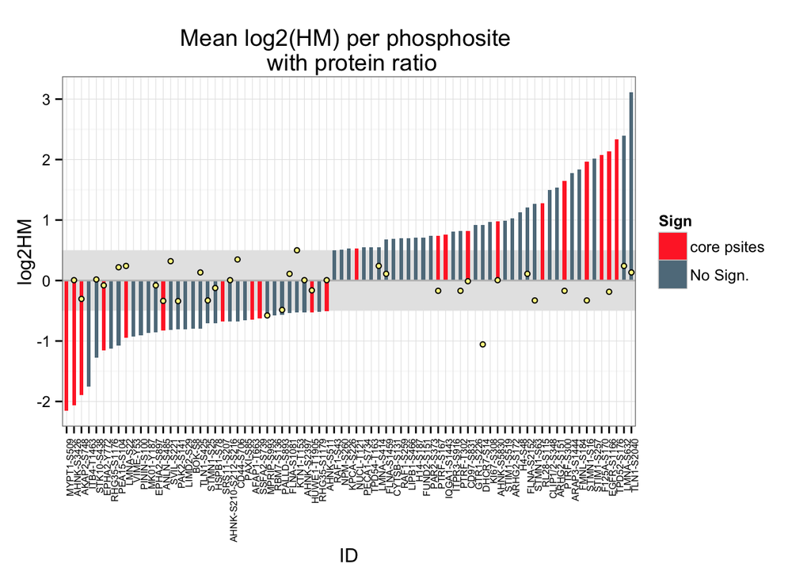

```r
###################################################################

tabtot$ID <- factor(as.character(tabtot$ID), levels = as.character(tabtot$ID[order(tabtot$FC)]))

log2HM <- c(tabtot$MedianProt, tabtot$FC)
type <- rep(c("Prot", "psite"), each = nrow(tabtot))
ID <- rep(tabtot$ID, 2)
Prot <- rep(tabtot$Uniprot, 2)
sign <- c("TPD52-S176", "EGFR-S1166", "F125A-S170", "STMN1-S16", "PTRF-S300", "RL28-S115", "AHNK-S5830", "CD97-S831", "IQGA1-S1443", "PTRF-S167", "NUCL-T121", "AHNK-S511", "HUWE1-T1905", "SSFA2-S739", "AFAP1-T663", "SRS11-S207", "ANLN-S485", "LMNA-S22", "EPHA2-Y772", "AKAP2-S748", "AHNK-S3426", "MYPT1-S509")
sign2 <- rep("No Sign.", length(ID))
sign2[ID %in% sign] <- "core psites"

df <- data.frame("log2HM" = log2HM, "type" = type, "ID" = ID, "Prot" = Prot, "Sign" = sign2)
df <- df[as.character(df$Prot)!="CLIP1",]
df$Prot <- factor(as.character(df$Prot), labels = sort(unique(as.character(df$Prot))))


subP <- subset(df, as.character(df$type) =="Prot")
subPhos <- subset(df, as.character(df$type) == "psite")

g <- ggplot(df, aes(y = log2HM, x = ID))

print(g + geom_rect(ymin = -0.5, ymax = 0.5, fill = "gray90", xmin = 0, xmax = length(unique(df$ID))+1) + geom_bar(data = subPhos, aes(y = log2HM, x = ID, fill = Sign), stat = "identity", width=.5)  + theme_bw() + theme(axis.text.x = element_text(angle = 90, hjust = 1, size = 6))  + geom_hline(yintercept = 0, col = "gray") + geom_point(data = subP, col = "black", size = 1.5, shape = 21, fill = "khaki1") + scale_fill_manual(values = c("firebrick1", "lightskyblue4")) + ggtitle("Mean log2(HM) per phosphosite \n with protein ratio"))
```

## HUVEC

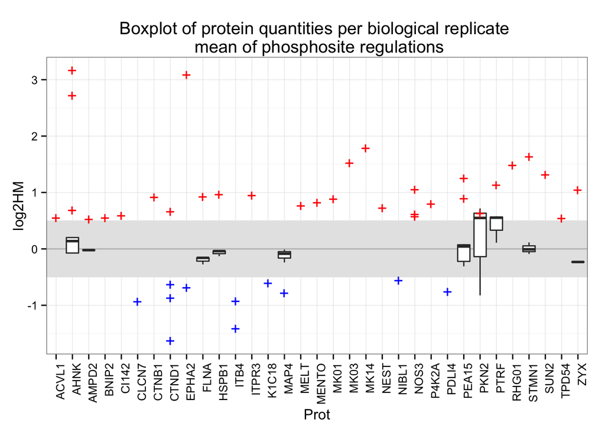

```r
tab <- read.csv("OutputTab/MediansHUV.csv")
tabsites <- read.csv("TopHitsHUVECAverages.csv")

Uniprot <- sapply(as.character(tab$Protein.Description), function(x) strsplit(x, " - [", fixed = T)[[1]][2])
Uniprot <- sapply(Uniprot, function(x) strsplit(x, "_")[[1]][1])
tab <- data.frame(tab, "Uniprot" = Uniprot)

tabsites <- tabsites[tabsites$FC >= 0.5 | tabsites$FC <= -0.5,]

tabtot <- merge(tab, tabsites, by = "Uniprot", all = T)

MedianProt <- sapply(1:nrow(tabtot), function(x) median(as.numeric(tabtot[x,c(3, 5, 7)]), na.rm = T))
tabtot <- data.frame(tabtot, "MedianProt" = MedianProt)

log2HM <- c(tabtot$Mean_MLP4, tabtot$Mean_MLP5, tabtot$Mean_MLP6, tabtot$FC)
type <- c(rep("Prot", (3*nrow(tabtot))), rep("psite", nrow(tabtot)))
ID <- rep(tabtot$ID, 4)
Prot <- rep(tabtot$Uniprot, 4)

df <- data.frame("log2HM" = log2HM, "type" = type, "ID" = ID, "Prot" = Prot)
df <- df[as.character(df$Prot)!="CLIP1",]
df$Prot <- factor(as.character(df$Prot), labels = sort(unique(as.character(df$Prot))))


subP <- subset(df, as.character(df$type) =="Prot")
subPhos <- subset(df, as.character(df$type) == "psite")
vec <- table(subPhos$Prot)
vec[vec==0] <- 1
l <- sapply(vec, function(x) c(1:x))
col <- unlist(l)
subPhos <- data.frame(subPhos[order(as.character(subPhos$Prot)),], "col"=as.character(col))

g <- ggplot(df, aes(y = log2HM, x = Prot))
print(g + geom_rect(ymin = -0.5, ymax = 0.5, fill = "gray90", xmin = 0, xmax = length(unique(df$Prot))+1) + geom_hline(yintercept = 0, col = "gray") + geom_boxplot(data = subP, aes(y = log2HM, x = Prot)) + geom_point(data = subPhos[subPhos$log2HM>=0.5,], col = "red", size = 5, shape = "+") + geom_point(data = subPhos[subPhos$log2HM <= -0.5,], col = "blue", size = 5, shape = "+") + theme_bw()  + theme(axis.text.x = element_text(angle = 90, hjust = 1)) + ggtitle("Boxplot of protein quantities per biological replicate \n mean of phosphosite regulations"))
```

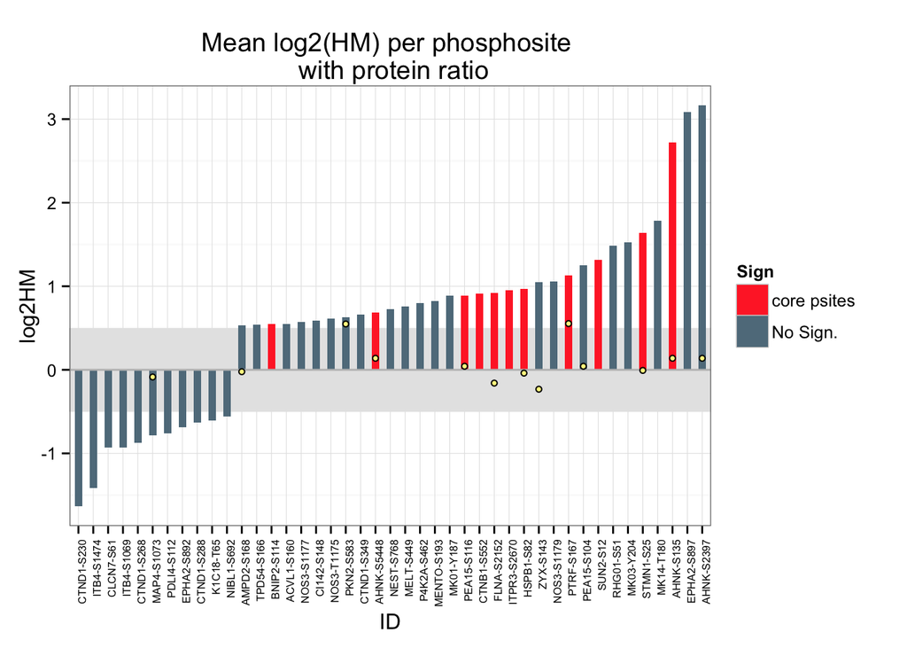

```r
###################################################################

tabtot$ID <- factor(as.character(tabtot$ID), levels = as.character(tabtot$ID[order(tabtot$FC)]))

log2HM <- c(tabtot$MedianProt, tabtot$FC)
type <- rep(c("Prot", "psite"), each = nrow(tabtot))
ID <- rep(tabtot$ID, 2)
Prot <- rep(tabtot$Uniprot, 2)
sign <- c("BNIP2-S114", "AHNK-S5448", "CTNB1-S552", "PEA15-S116", "ITPR3-S2670", "HSPB1-S82", "FLNA-S2152", "PTRF-S167", "SUN2-S12", "STMN1-S25", "AHNK-S135")
sign2 <- rep("No Sign.", length(ID))
sign2[ID %in% sign] <- "core psites"

df <- data.frame("log2HM" = log2HM, "type" = type, "ID" = ID, "Prot" = Prot, "Sign" = sign2)
df <- df[as.character(df$Prot)!="CLIP1",]
df$Prot <- factor(as.character(df$Prot), labels = sort(unique(as.character(df$Prot))))


subP <- subset(df, as.character(df$type) =="Prot")
subPhos <- subset(df, as.character(df$type) == "psite")

g <- ggplot(df, aes(y = log2HM, x = ID))

print(g + geom_rect(ymin = -0.5, ymax = 0.5, fill = "gray90", xmin = 0, xmax = length(unique(df$ID))+1) + geom_bar(data = subPhos, aes(y = log2HM, x = ID, fill = Sign), stat = "identity", width=.5)  + theme_bw() + theme(axis.text.x = element_text(angle = 90, hjust = 1, size = 6))  + geom_hline(yintercept = 0, col = "gray") + geom_point(data = subP, col = "black", size = 1.5, shape = 21, fill = "khaki1") + scale_fill_manual(values = c("firebrick1", "lightskyblue4")) + ggtitle("Mean log2(HM) per phosphosite \n with protein ratio"))
```

# Figure of EPHA2 and its phosphosites ratio

I plot the log2(H/M) per experiment of EPHA2 and its regulated phosphosites on the same graph.

```r
tab <- read.csv("OutputTab/MedianMDAs.csv")
tabsites <- read.csv("TopHitsMDAAverages.csv")

Uniprot <- sapply(as.character(tab$Protein.Description), function(x) strsplit(x, " - [", fixed = T)[[1]][2])
Uniprot <- sapply(Uniprot, function(x) strsplit(x, "_")[[1]][1])
tab <- data.frame(tab, "Uniprot" = Uniprot)

EA2 <- tab[tab$Uniprot=="EPHA2",]

tabsites <- tabsites[tabsites$FC >= 0.5 | tabsites$FC <= -0.5,]
tabsites <- tabsites[tabsites$Uniprot == "EPHA2",]
require(reshape)
tabsites <- melt(tabsites[,c(1:6, 8)])
tab2 <-  melt(EA2[,c(14, 2,4,6,8,10,12)])
```

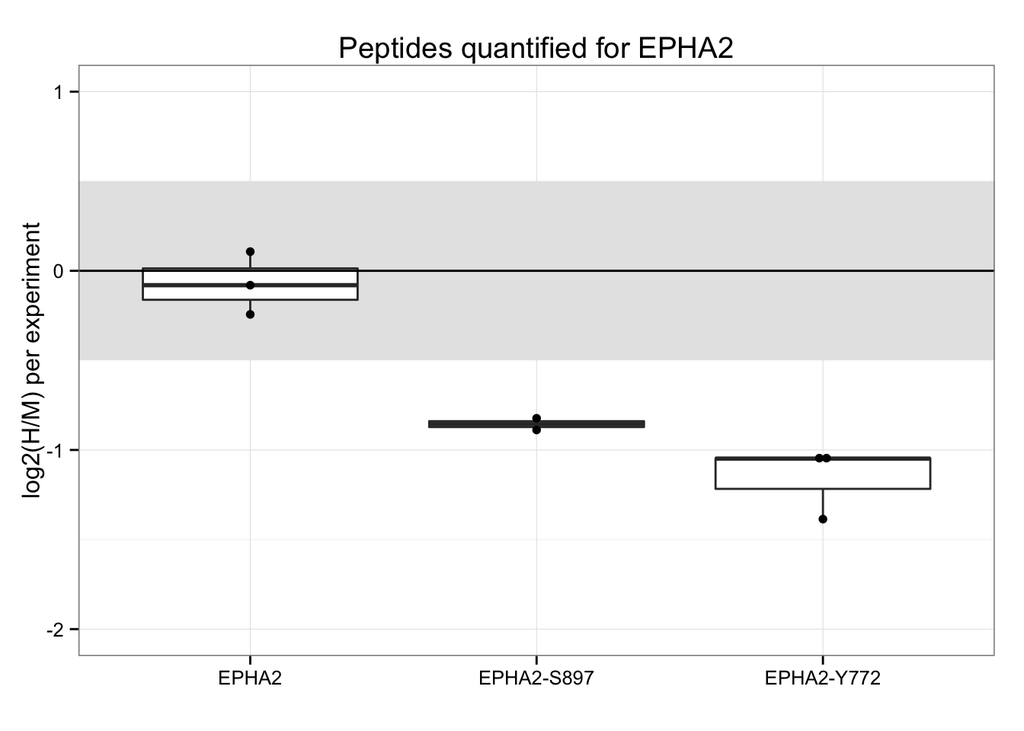

```r
tab2 <- cbind(tab2$Uniprot, tab2)
names(tab2) <- names(tabsites)

tab3 <- rbind(tab2, tabsites)
tab3 <- as.data.frame(tab3)
tab3$value <- as.numeric(as.character(tab3$value))

ggplot(tab3, aes(ID, value)) + geom_rect(ymin = -0.5, ymax = 0.5, xmin = 0, xmax = 4, fill = "grey90") + geom_boxplot() + geom_dotplot(binwidth = 0.04, binaxis='y', stackdir='center', dotsize=1) + scale_color_brewer(palette = "Set1") + theme_bw() + geom_hline(yintercept = 0) + ylab("log2(H/M) per experiment") + xlab("") + ggtitle("Peptides quantified for EPHA2") + ylim(-2, 1)
```